# Lab 8: MATH 4753

Dan Groeneveld

2020-10-20

## Task 1

```r
getwd()
```

```
## [1] "C:/Users/dangr/Desktop/STATS 2020/MATH4753GROE002/R/LABS/LAB 8"
```

## Task 2

Sample of n=10 from uniform distribution:

```r
samp = runif(10,0,5)
samp
```

```
##  [1] 4.4439110 3.5985525 2.8531346 0.7945935 0.5557301 2.8968708 4.0777268
##  [8] 4.4625165 2.8834557 1.3739615
```

Mean and variance for uniform distribution where a=0 and b=5:

```r
a = 0
b =5
mu = (a +b)/2
var = ((b-a)^2)/12
mu
```

```
## [1] 2.5
```

```r
var
```

```
## [1] 2.083333
```

Mean and variance from sample:

```r
xbar = mean(samp)
ssqr = var(samp)
xbar
```

```
## [1] 2.794045
```

```r
ssqr
```

```
## [1] 2.094165
```

Using the above theory:

$$\mu_T = \frac{n(b+a)}{2}$$

$$\mu_\bar{Y} = \frac{b+a}{2}$$

Explaining parts of the function myclt:

A - This part creates a sample of n from a uniform function with a and b (equal to 0 and 5 in the example) and then iterates the number of times given in the value iter. This object is then stored in the variable y.

B - This part turns the object y from before into a matrix with the number of rows equaling the sample size n and the number of columns equaling the number iterations iter. This matrix is stored in the variable data.

C - This part applies a sum to the columns of the matrix of data and stores these values in the variable sm.

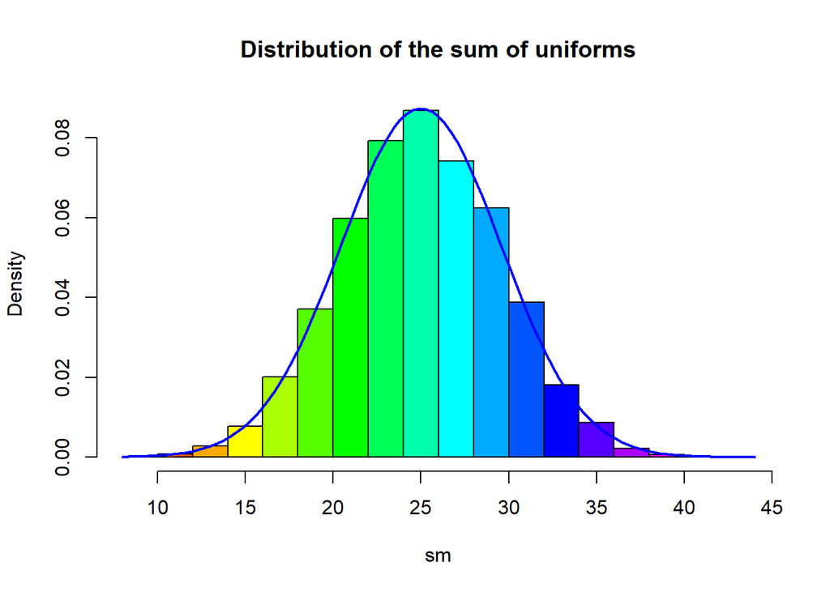

```r
myclt=function(n,iter,a=0,b=5){
y=runif(n*iter,a,b)
data=matrix(y,nr=n,nc=iter,byrow=TRUE)
sm=apply(data,2,sum)
h=hist(sm,plot=FALSE)
hist(sm,col=rainbow(length(h$mids)),freq=FALSE,main="Distribution of the sum of uniforms")
curve(dnorm(x,mean=n*(a+b)/2,sd=sqrt(n*(b-a)^2/12)),add=TRUE,lwd=2,col="Blue")
sm
}
w=myclt(n=10,iter=10000)
```

```r
wbar = mean(w)
ssqrw = var(w)
wbar
```

```
## [1] 24.98357
```

```r
ssqrw
```

```
## [1] 20.73947
```

Histogram of sample means and calculated values for w:

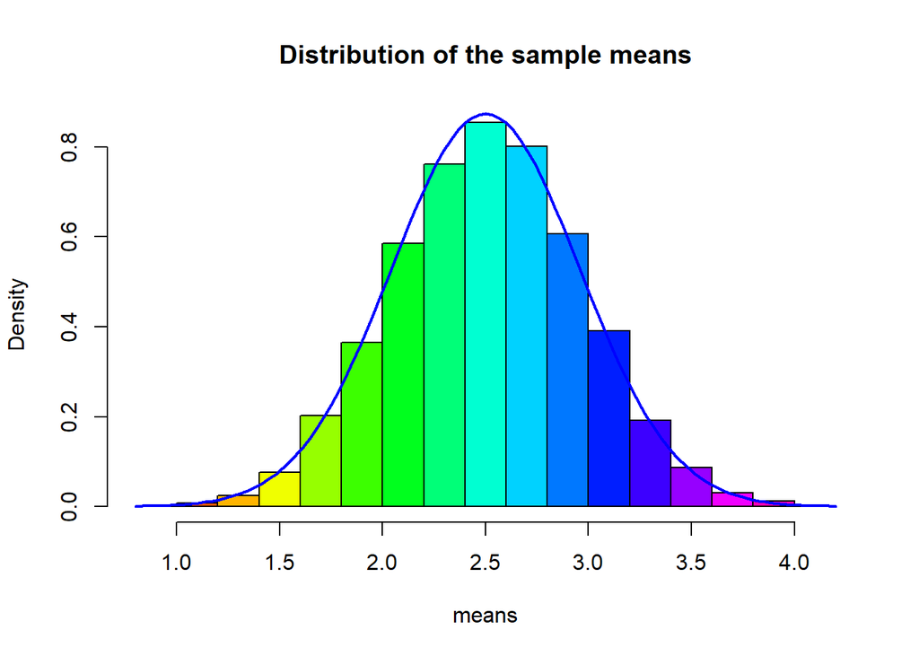

```r
mycltmeans=function(n,iter,a=0,b=5){
y=runif(n*iter,a,b)
data=matrix(y,nr=n,nc=iter,byrow=TRUE)
means=apply(data,2,mean)
h=hist(means,plot=FALSE)
hist(means,col=rainbow(length(h$mids)),freq=FALSE,main="Distribution of the sample means")
curve(dnorm(x,mean=(a+b)/2,sd=sqrt((b-a)^2/12/n)),add=TRUE,lwd=2,col="Blue")
means
}
w=mycltmeans(n=10,iter=10000)
```

```r
mean(w)
```

```
## [1] 2.508876
```

```r
var(w)
```

```
## [1] 0.2092471
```

## Task 3

Examining the function:

```r
mycltu=function(n,iter,a=0,b=10){
## r-random sample from the uniform
y=runif(n*iter,a,b)
## Place these numbers into a matrix
## The columns will correspond to the iteration and the rows will equal the sample size n
data=matrix(y,nr=n,nc=iter,byrow=TRUE)
## apply the function mean to the columns (2) of the matrix
## these are placed in a vector w
w=apply(data,2,mean)
## We will make a histogram of the values in w
## How high should we make y axis?
## All the values used to make a histogram are placed in param (nothing is plotted yet)
param=hist(w,plot=FALSE)
## Since the histogram will be a density plot we will find the max density

ymax=max(param$density)
## To be on the safe side we will add 10% more to this
ymax=1.1*ymax
## Now we can make the histogram
hist(w,freq=FALSE,  ylim=c(0,ymax), main=paste("Histogram of sample mean",
"\n", "sample size= ",n,sep=""),xlab="Sample mean")
## add a density curve made from the sample distribution
lines(density(w),col="Blue",lwd=3) # add a density plot
## Add a theoretical normal curve
curve(dnorm(x,mean=(a+b)/2,sd=(b-a)/(sqrt(12*n))),add=TRUE,col="Red",lty=2,lwd=3) # add a theoretical curve
## Add the density from which the samples were taken
curve(dunif(x,a,b),add=TRUE,lwd=4)

}
```

The 2 in the apply function means that the mean of each column of data is taken.

sd takes the form as shown in the equation because this is what the standard deviation of a sample taken from a uniform function will approach as n tends toward infinity.

Plots:

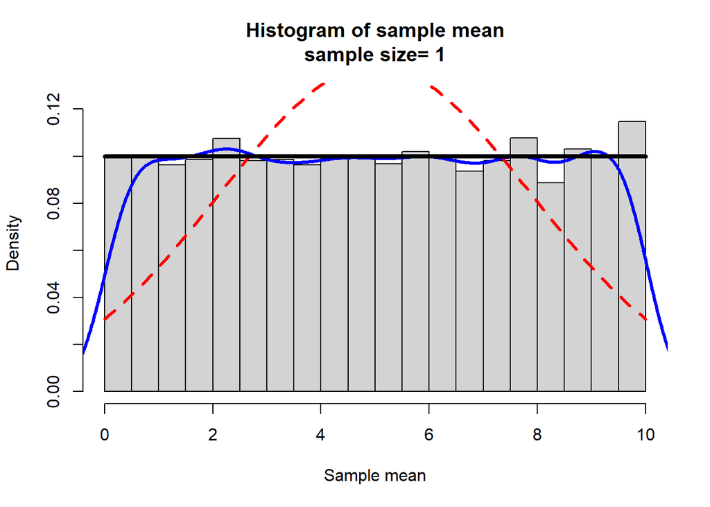

```r
mycltu(n=1,iter=10000)
```

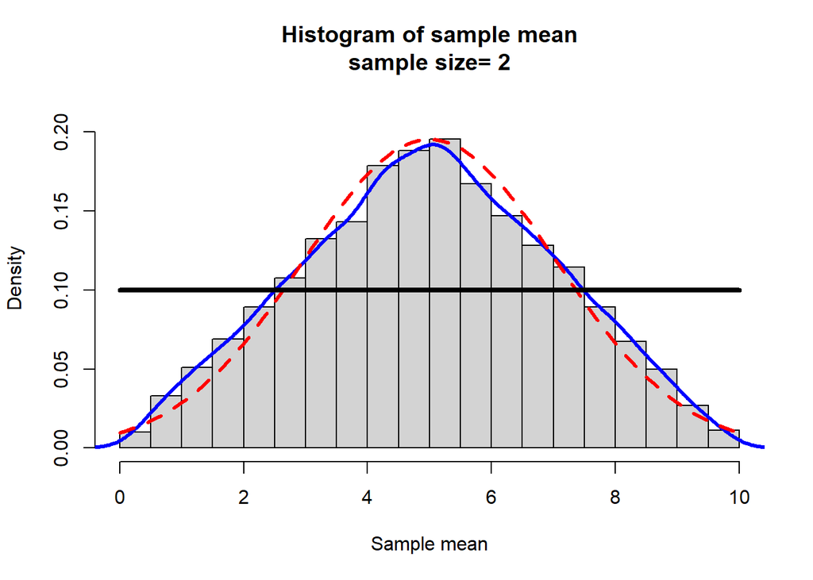

```r
mycltu(n=2,iter=10000)
```

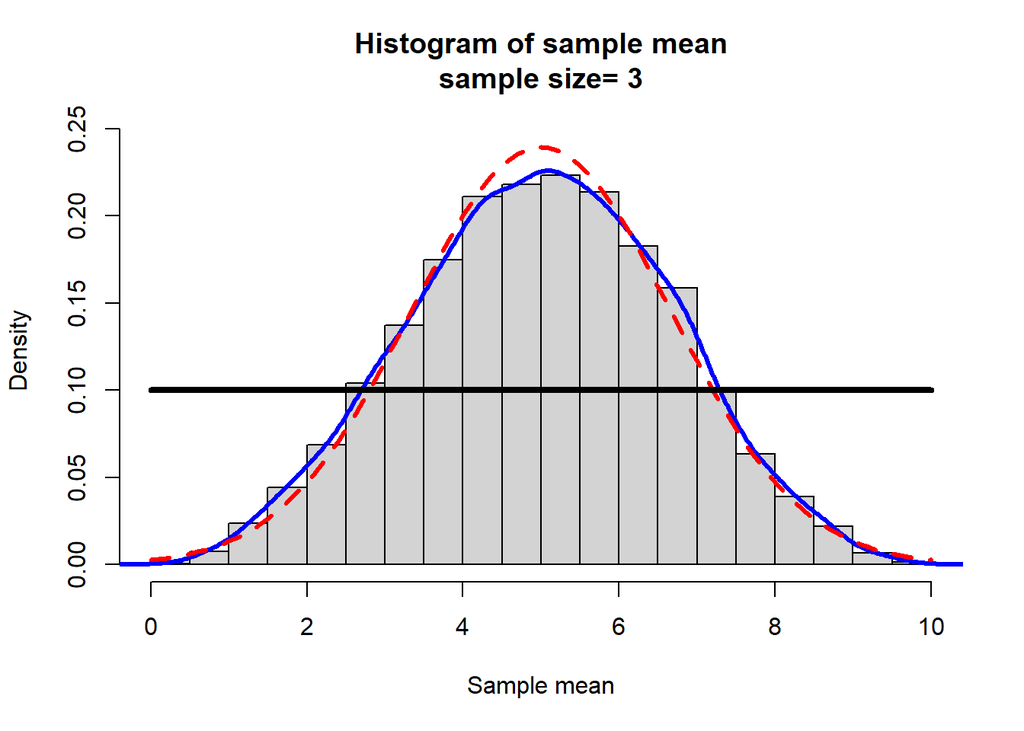

```r
mycltu(n=3,iter=10000)
```

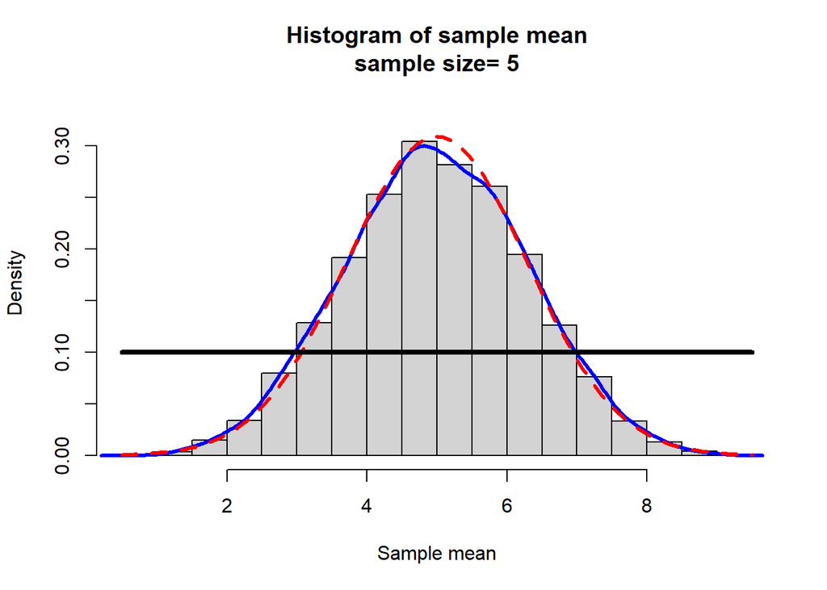

```r
mycltu(n=5,iter=10000)
```

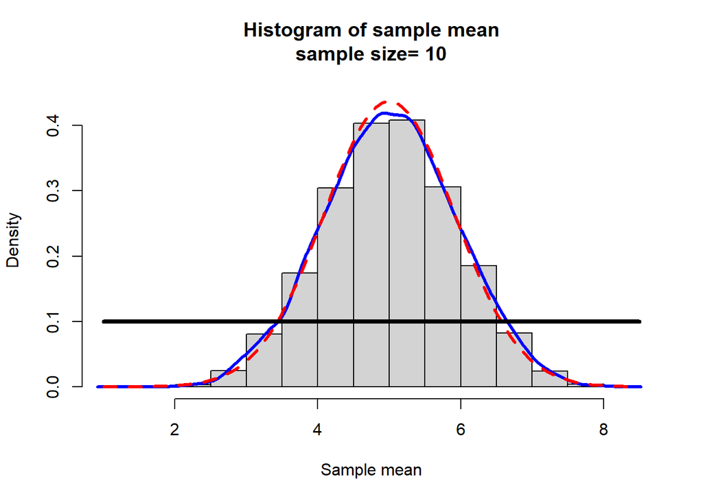

```r
mycltu(n=10,iter=10000)
```

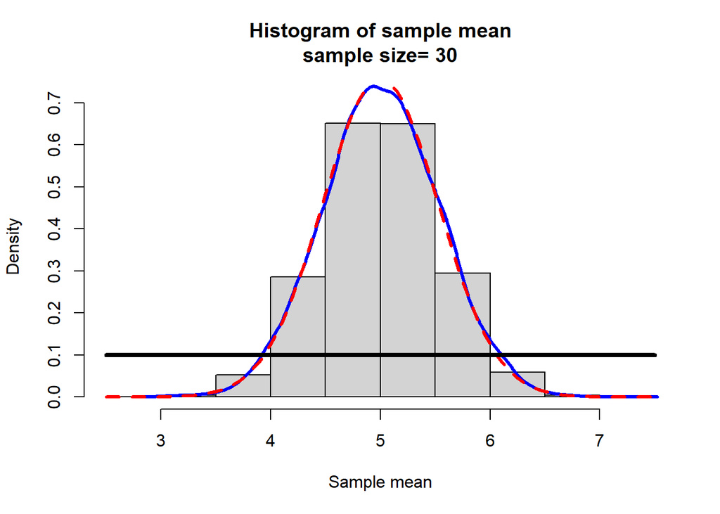

```r
mycltu(n=30,iter=10000)
```

I conclude that with increasing n (the sample size) the distribution of the sample means is better approximated by a normal function with mean:
$$\mu = \frac{b+a}{2}$$

## Task 4

Samples from the binomial distribution:

```r
mycltb=function(n,iter,p=0.5,...){

## r-random sample from the Binomial
y=rbinom(n*iter,size=n,prob=p)
## Place these numbers into a matrix
## The columns will correspond to the iteration and the rows will equal the sample size n
data=matrix(y,nr=n,nc=iter,byrow=TRUE)
## apply the function mean to the columns (2) of the matrix
## these are placed in a vector w
w=apply(data,2,mean)
## We will make a histogram of the values in w
## How high should we make y axis?
## All the values used to make a histogram are placed in param (nothing is plotted yet)
param=hist(w,plot=FALSE)
## Since the histogram will be a density plot we will find the max density

ymax=max(param$density)
## To be on the safe side we will add 10% more to this
ymax=1.1*ymax

## Now we can make the histogram
## freq=FALSE means take a density
hist(w,freq=FALSE,  ylim=c(0,ymax),
main=paste("Histogram of sample mean","\n", "sample size= ",n,sep=""),
xlab="Sample mean",...)
## add a density curve made from the sample distribution
#lines(density(w),col="Blue",lwd=3) # add a density plot
## Add a theoretical normal curve
curve(dnorm(x,mean=n*p,sd=sqrt(p*(1-p))),add=TRUE,col="Red",lty=2,lwd=3)

}
```

### p = 0.3

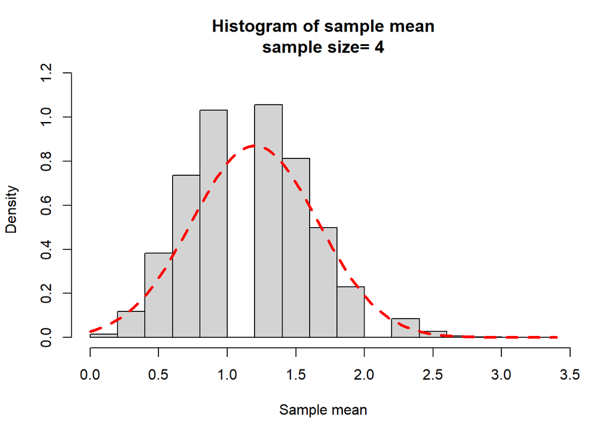

```r
mycltb(n=4,iter=10000,p=0.3)
```

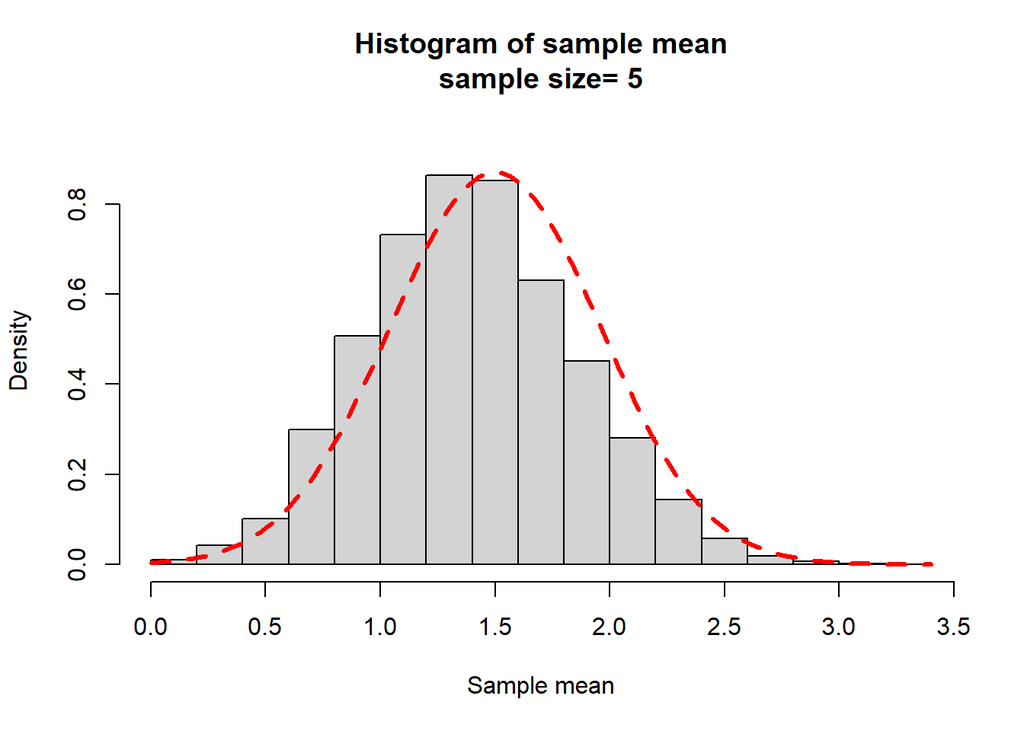

```r
mycltb(n=5,iter=10000,p=0.3)
```

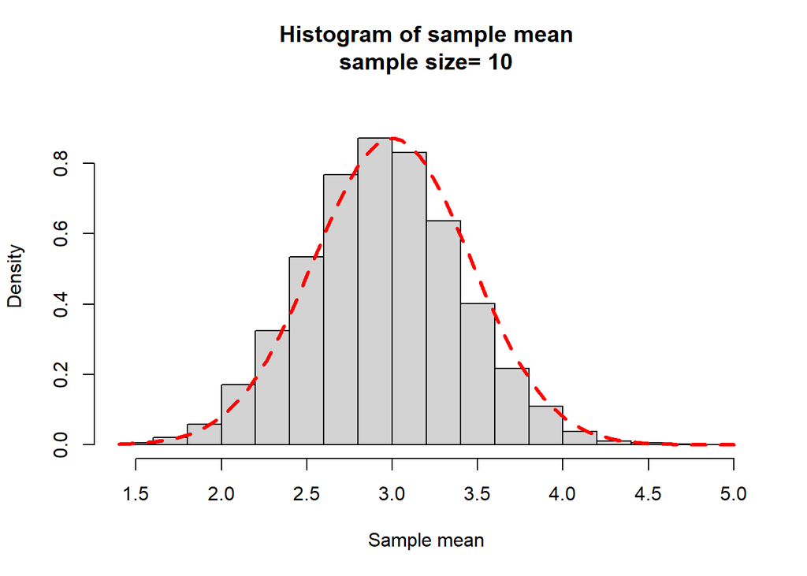

```r
mycltb(n=10,iter=10000,p=0.3)
```

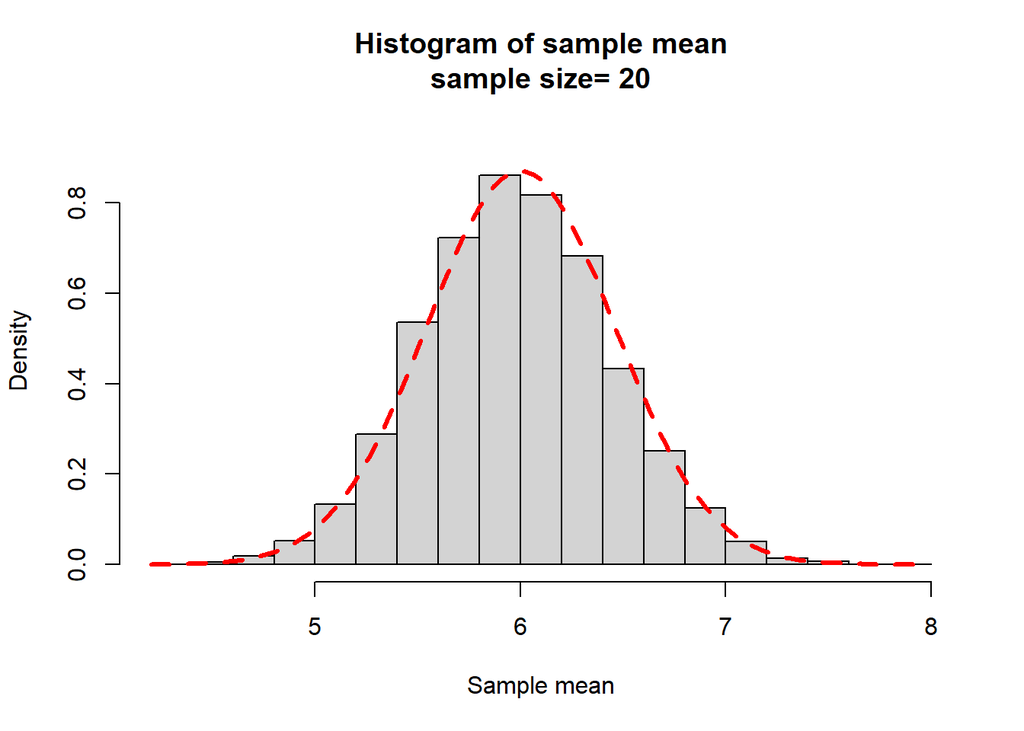

```r
mycltb(n=20,iter=10000,p=0.3)
```

### p = 0.7

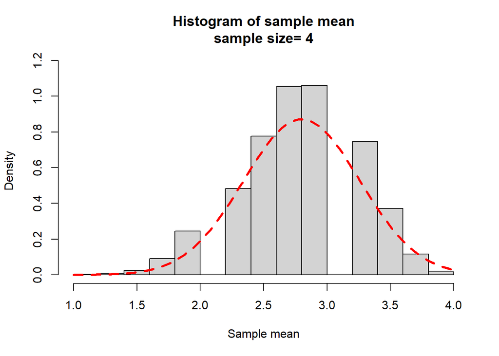

```r
mycltb(n=4,iter=10000,p=0.7)
```

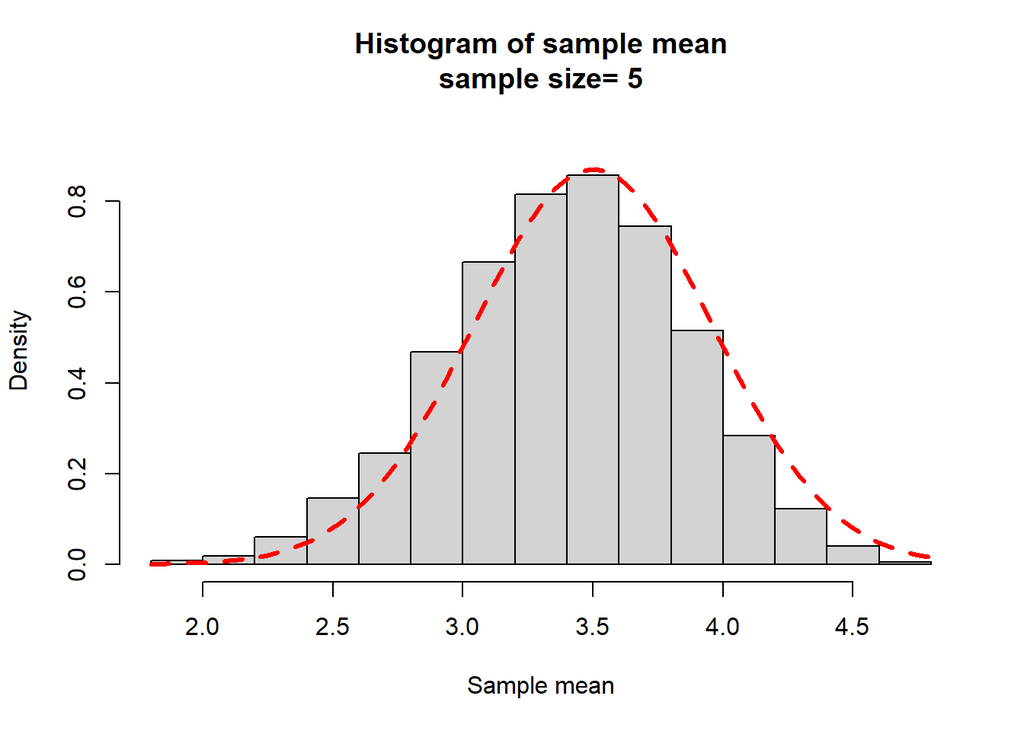

```r
mycltb(n=5,iter=10000,p=0.7)
```

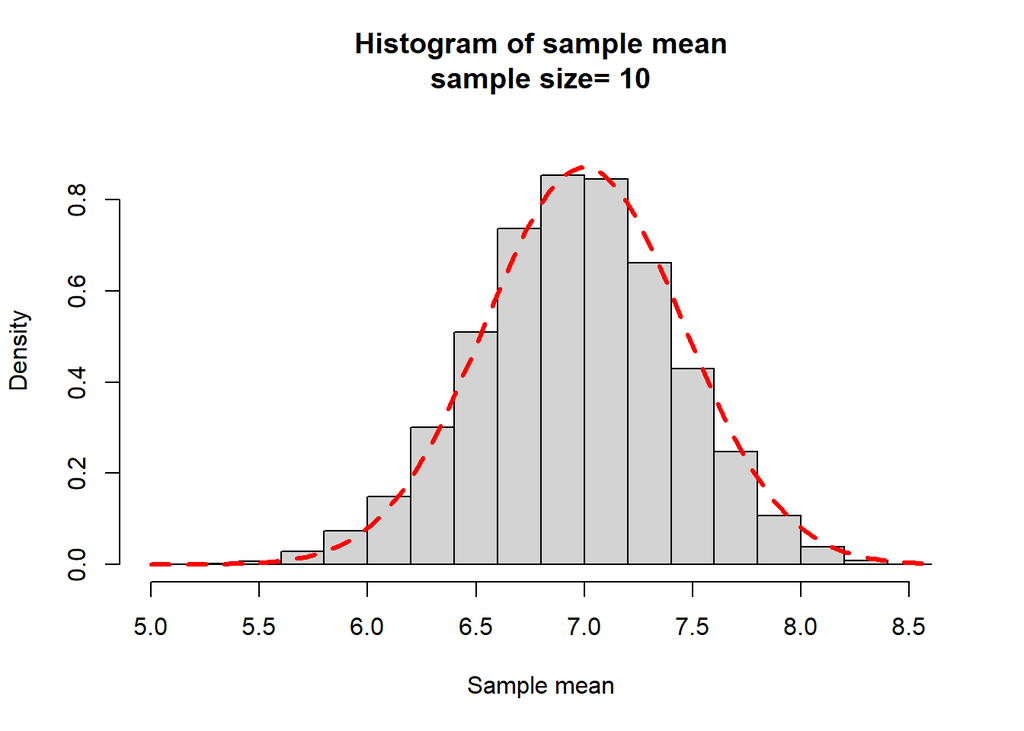

```r
mycltb(n=10,iter=10000,p=0.7)
```

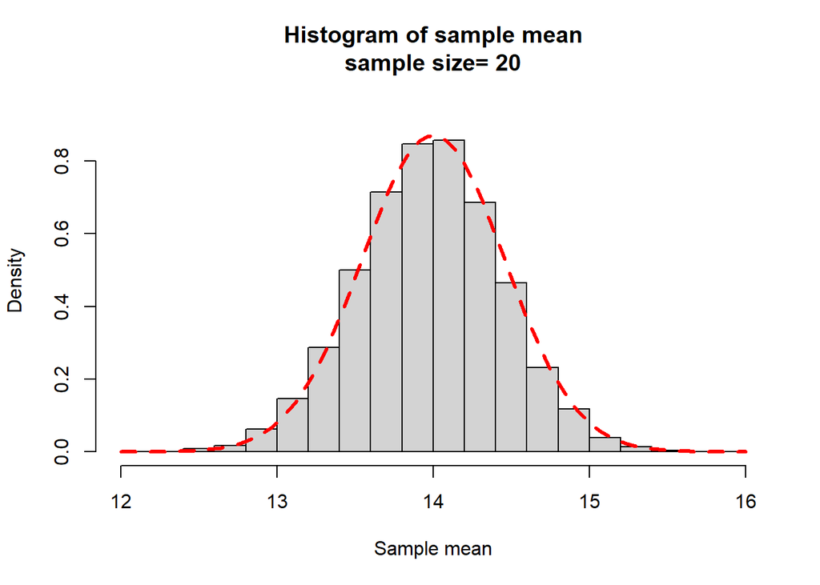

```r
mycltb(n=20,iter=10000,p=0.7)
```

### p = 0.5

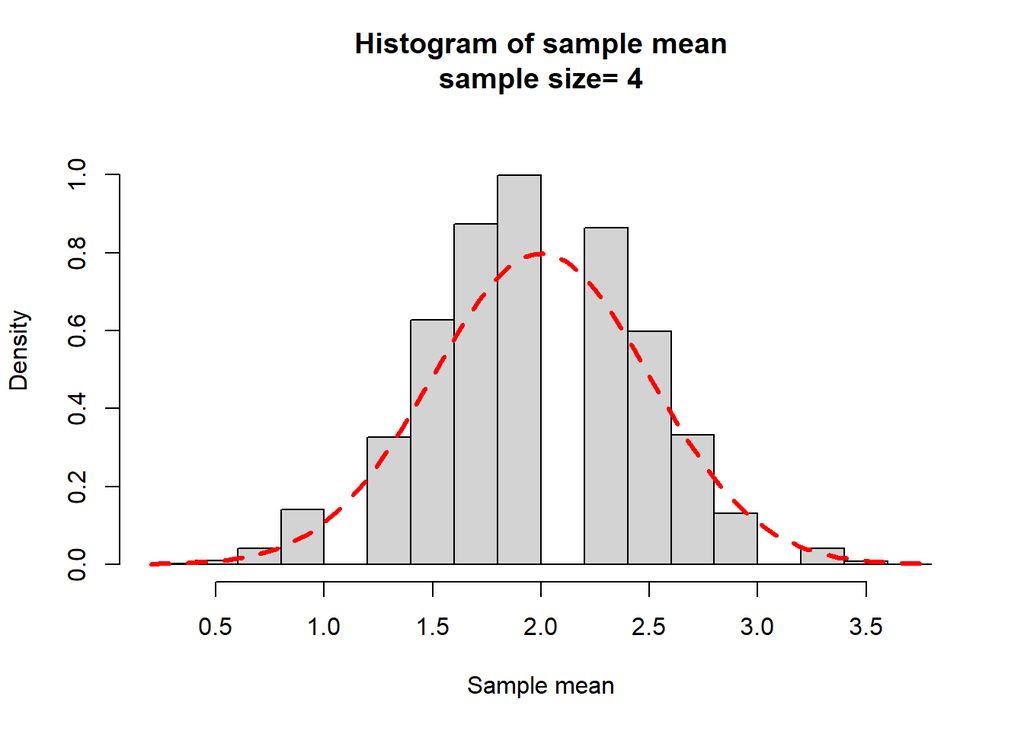

```r
mycltb(n=4,iter=10000,p=0.5)
```

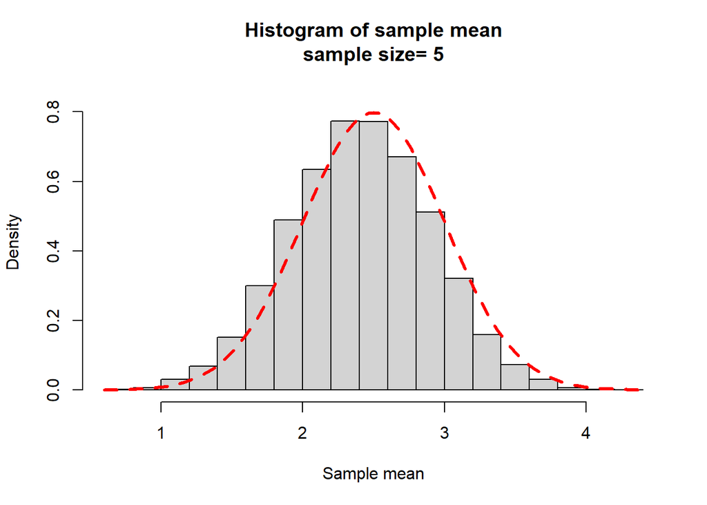

```r
mycltb(n=5,iter=10000,p=0.5)
```

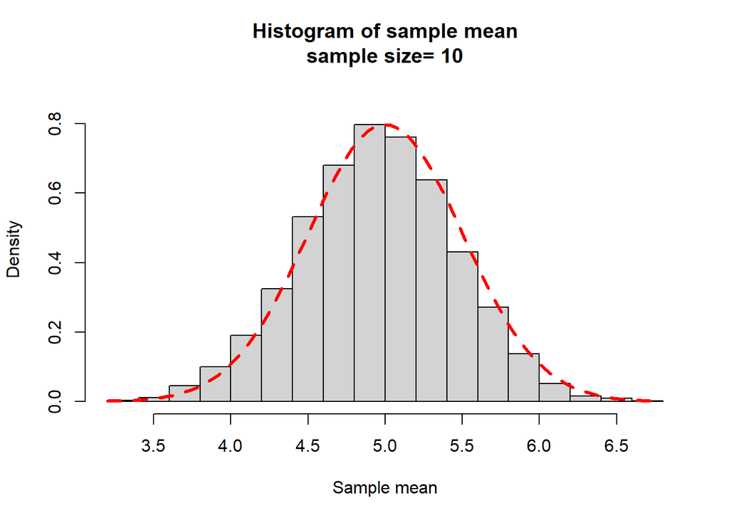

```r
mycltb(n=10,iter=10000,p=0.5)
```

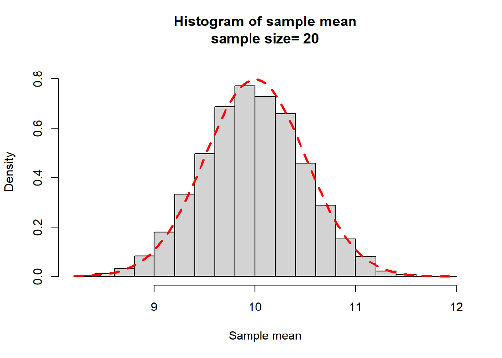

```r
mycltb(n=20,iter=10000,p=0.5)
```

## Task 5

Samples from a poisson distribution:

```r
mycltp=function(n,iter,lambda=10,...){

## r-random sample from the Poisson
y=rpois(n*iter,lambda=lambda)
## Place these numbers into a matrix
## The columns will correspond to the iteration and the rows will equal the sample size n
data=matrix(y,nr=n,nc=iter,byrow=TRUE)
## apply the function mean to the columns (2) of the matrix
## these are placed in a vector w
w=apply(data,2,mean)
## We will make a histogram of the values in w
## How high should we make y axis?
## All the values used to make a histogram are placed in param (nothing is plotted yet)
param=hist(w,plot=FALSE)
## Since the histogram will be a density plot we will find the max density

ymax=max(param$density)
## To be on the safe side we will add 10% more to this
ymax=1.1*ymax

## Make a suitable layout for graphing
layout(matrix(c(1,1,2,3),nr=2,nc=2, byrow=TRUE))

## Now we can make the histogram
hist(w,freq=FALSE,  ylim=c(0,ymax), col=rainbow(max(w)),
main=paste("Histogram of sample mean","\n", "sample size= ",n," iter=",iter," lambda=",lambda,sep=""),
xlab="Sample mean",...)
## add a density curve made from the sample distribution
#lines(density(w),col="Blue",lwd=3) # add a density plot
## Add a theoretical normal curve
curve(dnorm(x,mean=lambda,sd=sqrt(lambda/n)),add=TRUE,col="Red",lty=2,lwd=3) # add a theoretical curve

# Now make a new plot
# Since y is discrete we should use a barplot
barplot(table(y)/(n*iter),col=rainbow(max(y)), main="Barplot of sampled y", ylab ="Rel. Freq",xlab="y" )
x=0:max(y)
plot(x,dpois(x,lambda=lambda),type="h",lwd=5,col=rainbow(max(y)),
main="Probability function for Poisson", ylab="Probability",xlab="y")
}
```

### lambda = 4

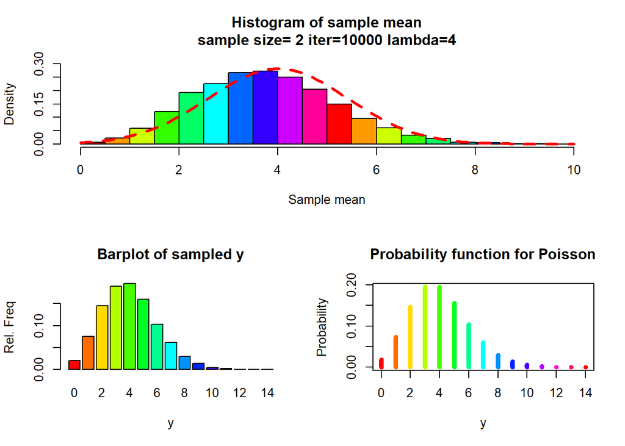

```r
mycltp(n=2,iter=10000, lambda = 4)
```

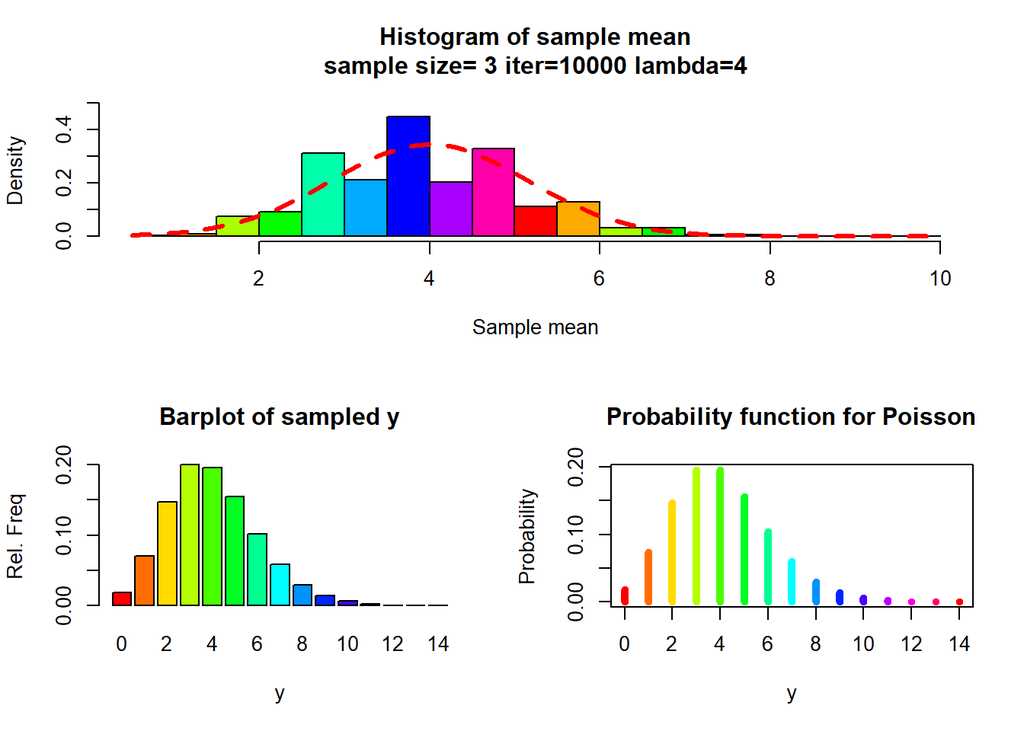

```r
mycltp(n=3,iter=10000, lambda = 4)
```

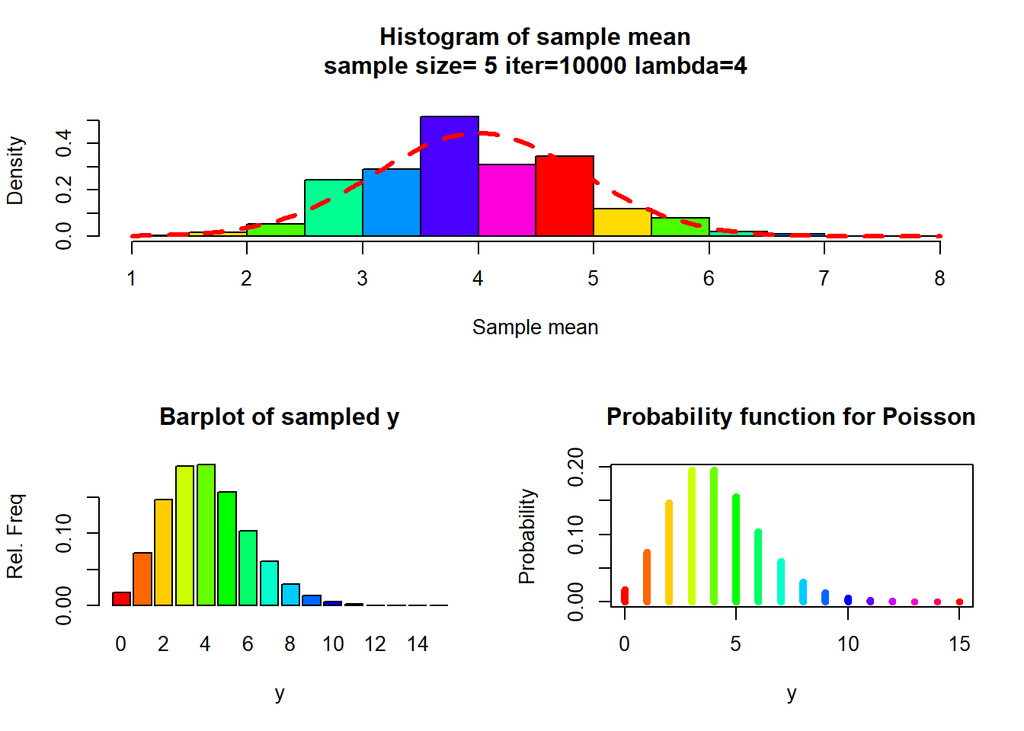

```r
mycltp(n=5,iter=10000, lambda = 4)
```

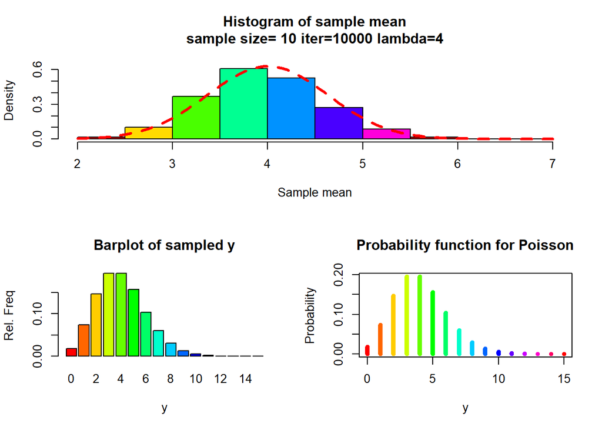

```r
mycltp(n=10,iter=10000, lambda = 4)
```

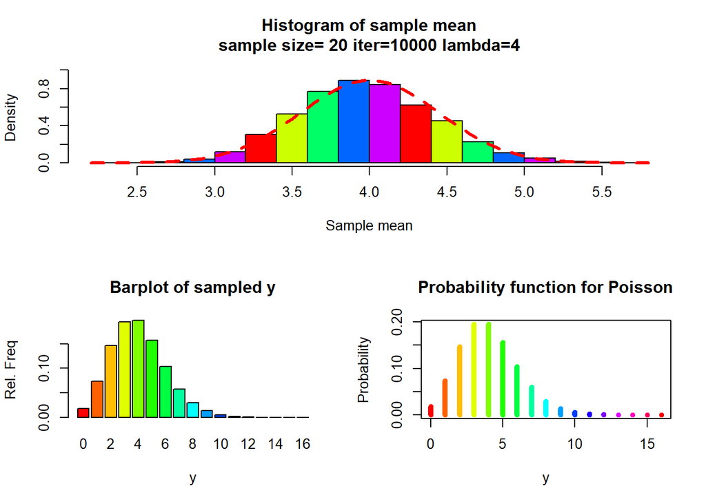

```r
mycltp(n=20,iter=10000, lambda = 4)
```

### lambda = 10

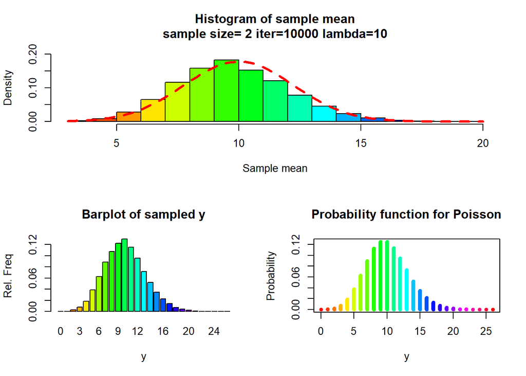

```r
mycltp(n=2,iter=10000, lambda = 10)
```

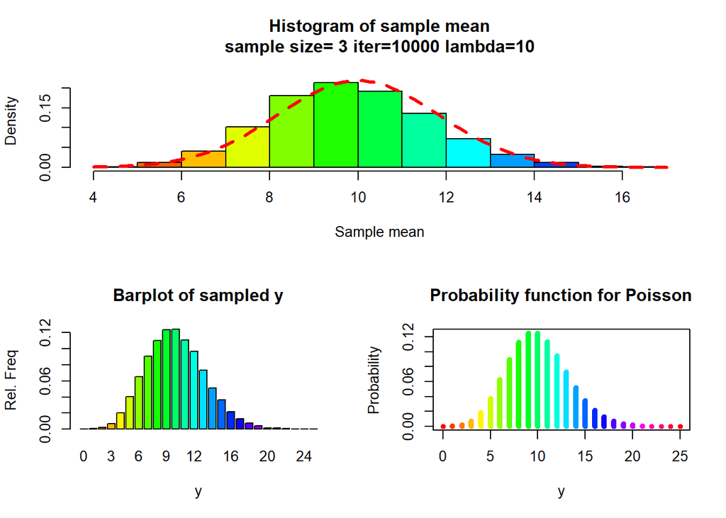

```r
mycltp(n=3,iter=10000, lambda = 10)
```

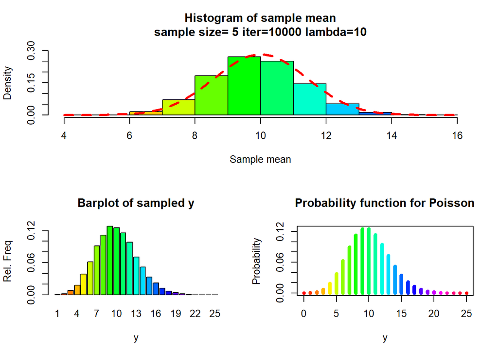

```r
mycltp(n=5,iter=10000, lambda = 10)
```

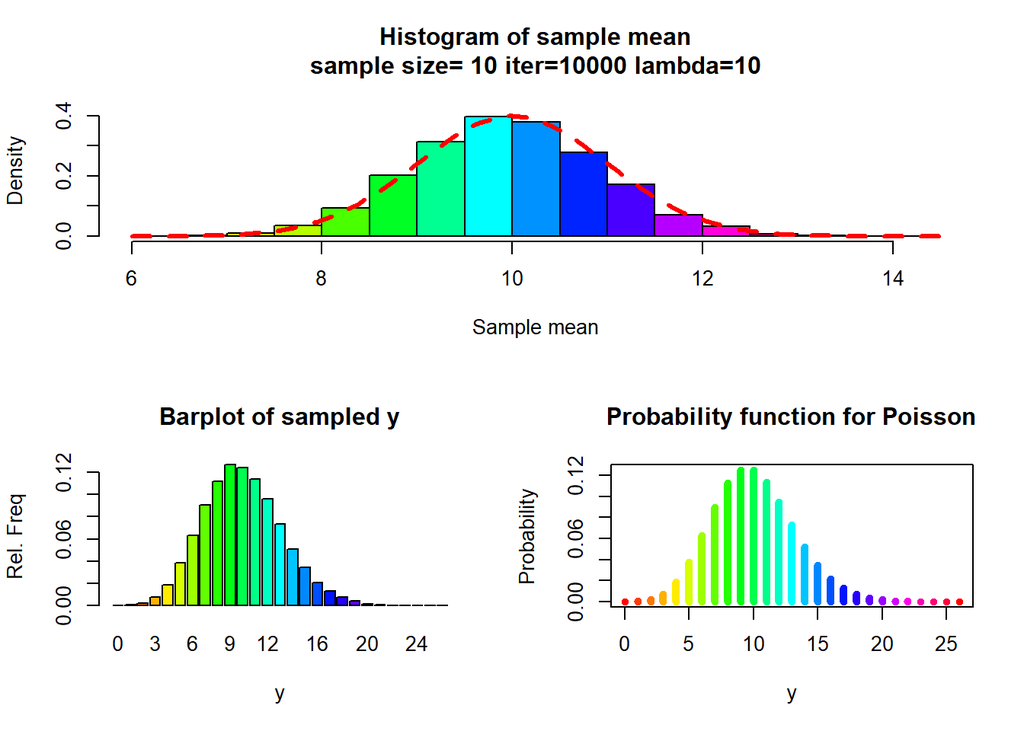

```r
mycltp(n=10,iter=10000, lambda = 10)
```

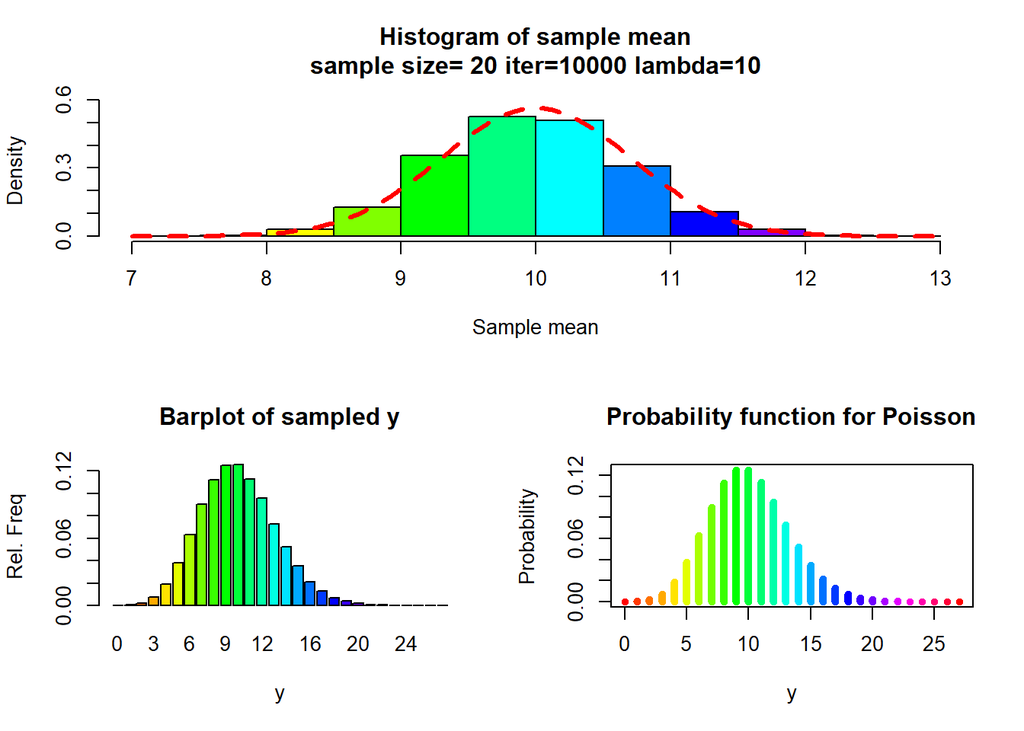

```r
mycltp(n=20,iter=10000, lambda = 10)
```

## Task 6

Installing the package (this was done and then blocked out to avoid screeds of output)

```r
#devtools::install(build_vignettes=TRUE)
```

Calling the function:

```r
w = MATH4753GROE002::mycltdangroeneveld(n=10, iter =10000)
```

[figure not shown]